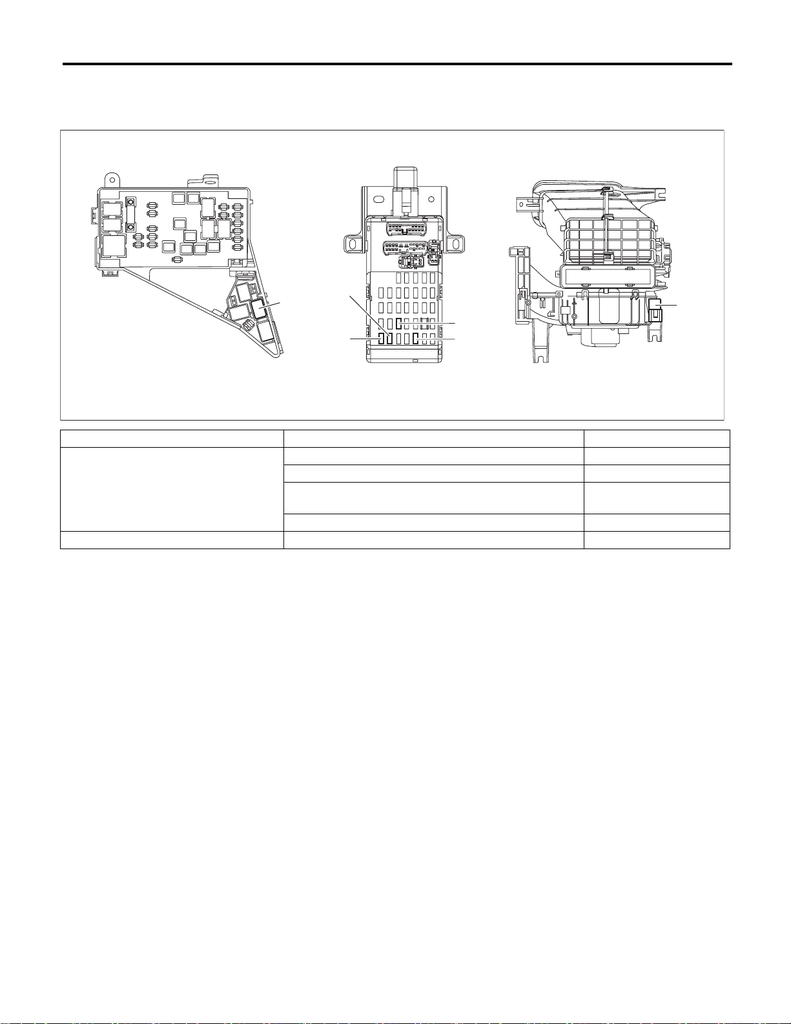

AC-32

Relay and Fuse

HVAC SYSTEM (HEATER, VENTILATOR AND A/C)

7. Relay and Fuse

A: LOCATION

NOTE:

For other related fuses, refer to the wiring diagram. <Ref. to WI-28, Power Supply Circuit.>

Main fuse box A/C relay (A)

Relay & fuse box

Fuse 15 A (blower motor relay) (B)

Fuse 15 A (blower motor relay) (C)

Fuse 10 A (A/C control panel, A/C relay, sub fan relay,

pressure switch and blower motor relay)

(D)

Fuse 7.5 A (A/C control panel) (E)

Blower motor unit Blower motor relay (F)

AC-03522

M/B F/B B/U

(D)

(E)

(C)

(B)

(F)

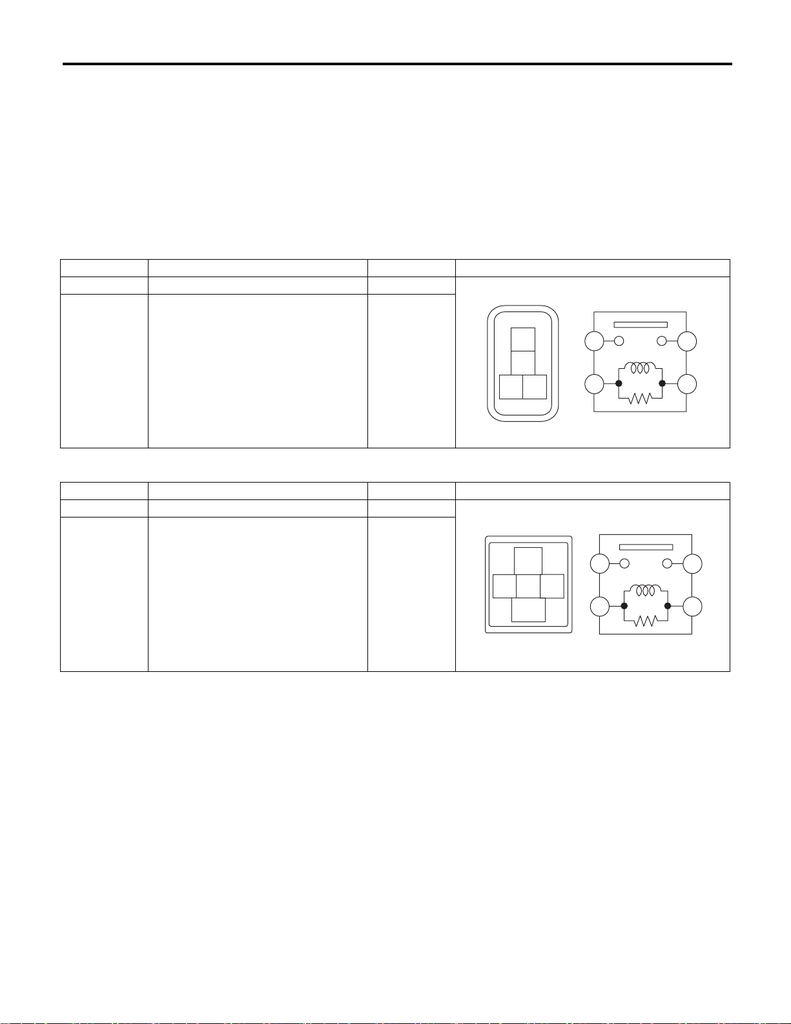

AC-33

Relay and Fuse

HVAC SYSTEM (HEATER, VENTILATOR AND A/C)

B: INSPECTION

1. CHECK FUSE

1) Remove the fuse and inspect visually.

2) If the fuse is blown out, replace the fuse.

NOTE:

If the fuse is blown again, check the system wiring harness.

2. CHECK RELAY

1) Measure the resistance between relay terminals.

• A/C relay

• Blower motor relay

2) Replace the relay if the inspection result is not within the standard value.

Terminal No. Inspection conditions Standard Circuit

1 — 2 Always 1 MΩ or more

1 — 2

Apply battery voltage between terminals

4 and 3.

Less than 1 Ω

Terminal No. Inspection conditions Standard Circuit

1 — 4 Always 1 MΩ or more

1 — 4

Apply battery voltage between terminals

2 and 3.

Less than 1 Ω

LI-01273

2

34

2

3 4

1

AC-02796

2

3

4

4

2 3

1